# Predicting the Future of Water Stress

By: Spencer Potter

## The Importance of Water Stress and Availability

Water is a limited resource that all humans need to survive. Furthermore countries are reliant on water to sustain agriculture, help generate energy, and to aid in the creation of many things in industry. The main withdrawal of fresh water is for agriculture at 70 percent, according to the world bank (https://www.worldbank.org/en/topic/water-in-agriculture). As these resources dwindle, conflicts will arise around the world. This can be seen all over the world, from California where farmers are in conflict with Los Angeles, and over the Euphrates and Tigres river where Iraq, Turkey, and Syria are in tension over the use of the rivers.

The purpose of this project is to look at data about water stress in the Americas, explore what variables seem to have an impact on water stress, visualize these connections, and try to predict water stress in the future. This would allow regions to come to agreements and rationalizations before the water stress is on the country.

# Outline

- Data Exploration
- Data Pre-Processing
- Visualization of Data
- Data Analysis and Regression

# Data Exploration

The data has four variables

1. water stress, this is a metric that shows how much stress a region is under. This is a measure of how much water is being used as opposed to the available water
2. dependency ratio, this is a percentage that shows how dependent on water imports a country is
3. total renewable water per capita, this is a measure of how much renewable water a country has per person
4. freshwater withdrawal as percent of total renewable water resources, this shows how much water is being pulled in relation to total resources

This data was pulled from AQUASTAT and includes some metrics that are not important and does not include some that would be helpful for graphing. To look at only region we will need to add a new column in pre-processing.

# Data Pre-Processing

The csv was obtained by going to https://tableau.apps.fao.org/views/ReviewDashboard-v1/region_dashboard?%3Aembed=y&%3AisGuestRedirectFromVizportal=y and selecting the target variables (dependency ratio, water stress, total renewable water per capita, and Freshwater withdrawal as % of total renewable water resources) and regions (Central America, North America, South America).

```python
import pandas as pd
import numpy as np
import seaborn as sns
import statsmodels.api as sm
import statsmodels.formula.api as smf
from sklearn.model_selection import train_test_split
```

```python
# Loading the data
data = pd.read_csv('/content/drive/MyDrive/final_project/dataset_water.csv')
data
```

|  | Country | M49 | Year | Variable | Unit | value | Symbol | Symbol Description |
| --- | --- | --- | --- | --- | --- | --- | --- | --- |
| 0 | Argentina | 32 | 2019 | Dependency ratio | (%) | 66.675797 | I | Imputed (carry forward, vertical imputation, l... |
| 1 | Argentina | 32 | 2018 | Dependency ratio | (%) | 66.675797 | E | Estimate either calculated as sum or identify ... |
| 2 | Argentina | 32 | 2017 | Dependency ratio | (%) | 66.675797 | E | Estimate either calculated as sum or identify ... |
| 3 | Argentina | 32 | 2016 | Dependency ratio | (%) | 66.675797 | E | Estimate either calculated as sum or identify ... |
| 4 | Argentina | 32 | 2015 | Dependency ratio | (%) | 66.675797 | E | Estimate either calculated as sum or identify ... |
| ... | ... | ... | ... | ... | ... | ... | ... | ... |
| 2419 | Venezuela (Bolivarian Republic of) | 862 | 1994 | Total renewable water resources per capita | (m3/inhab/year) | 61700.946550 | E | Estimate either calculated as sum or identify ... |
| 2420 | Venezuela (Bolivarian Republic of) | 862 | 1993 | Total renewable water resources per capita | (m3/inhab/year) | 63044.499280 | E | Estimate either calculated as sum or identify ... |
| 2421 | Venezuela (Bolivarian Republic of) | 862 | 1992 | Total renewable water resources per capita | (m3/inhab/year) | 64452.788770 | E | Estimate either calculated as sum or identify ... |
| 2422 | Venezuela (Bolivarian Republic of) | 862 | 1991 | Total renewable water resources per capita | (m3/inhab/year) | 65932.479070 | E | Estimate either calculated as sum or identify ... |
| 2423 | Venezuela (Bolivarian Republic of) | 862 | 1990 | Total renewable water resources per capita | (m3/inhab/year) | 67489.563950 | E | Estimate either calculated as sum or identify ... |

2424 rows × 8 columns

# Pre-Processing

The data right now is in a rather ugly, confusing format. To clean it, dropping some columns and reformatting is needed. Specifically, all the variables should be in seperate columns.

Upon further exploration the data is really ugly to work with. If a value was requested from AQUASTAT and the target country and year did not have that value it was simply exluded and not represented as a NAN value.

```python
data = data.drop(columns=['M49', 'Symbol', 'Symbol Description']) # these are not necessary
data = data[data.Year > 2000] # this trims off years that have no data

# The following countries do not have data for the time period we are interested in
data = data[data.Country != 'Costa Rica']
data = data[data.Country != 'Honduras']
data = data[data.Country != 'Panama']
data = data[data.Country != 'Peru']
```

```python
# Check for null
data.isnull().any()
```

```
Country     False
Year        False
Variable    False
Unit        False
value       False
dtype: bool
```

This code is going through and converting the format into one where the variables are stored in their own seperate column as opposed to one column. This will make it easier to graph the data and slice it as one sees fit.

```python
# This for loops is going through the dataframe grabbing the dependency ratio, fresh water, water stress, and total renewable water values for the given country and year
# Then it sets the new columns as these values
for idx, row in data.iterrows():
  dep_ratio = data[(data['Variable'] == 'Dependency ratio') & (data['Country'] == row.Country) & (data['Year'] == row.Year)].values
  fresh_w = data[(data['Variable'] == 'MDG 7.5. Freshwater withdrawal as % of total renewable water resources') & (data['Country'] == row.Country) & (data['Year'] == row.Year)].values
  wat_str = data[(data['Variable'] == 'SDG 6.4.2. Water Stress') & (data['Country'] == row.Country) & (data['Year'] == row.Year)].values
  renew = data[(data['Variable'] == 'Total renewable water resources per capita') & (data['Country'] == row.Country) & (data['Year'] == row.Year)].values


  data.at[idx, 'Dependency_Ratio'] = dep_ratio[0][4]
  data.at[idx, 'Fresh_Water'] = fresh_w[0][4]
  data.at[idx, 'Water_Stress'] = wat_str[0][4]
  data.at[idx, 'Total_renewable'] = renew[0][4]
```

```python
# This drops the columns that are no longer needed
data = data.drop(columns=['Variable', 'Unit', 'value'])
data
```

|  | Country | Year | Dependency_Ratio | Fresh_Water | Water_Stress | Total_renewable |
| --- | --- | --- | --- | --- | --- | --- |
| 0 | Argentina | 2019 | 66.675797 | 4.301333 | 10.456664 | 19567.36831 |
| 1 | Argentina | 2018 | 66.675797 | 4.301333 | 10.456664 | 19752.41850 |
| 2 | Argentina | 2017 | 66.675797 | 4.301333 | 10.456664 | 19943.03680 |
| 3 | Argentina | 2016 | 66.675797 | 4.301333 | 10.456664 | 20139.53148 |
| 4 | Argentina | 2015 | 66.675797 | 4.301333 | 10.456664 | 20341.99739 |
| ... | ... | ... | ... | ... | ... | ... |
| 2408 | Venezuela (Bolivarian Republic of) | 2005 | 39.956739 | 1.415760 | 6.012385 | 50721.75119 |
| 2409 | Venezuela (Bolivarian Republic of) | 2004 | 39.956739 | 1.267745 | 5.383801 | 51572.14057 |
| 2410 | Venezuela (Bolivarian Republic of) | 2003 | 39.956739 | 1.119730 | 4.755217 | 52470.24612 |
| 2411 | Venezuela (Bolivarian Republic of) | 2002 | 39.245283 | 0.983229 | 4.342593 | 52787.98655 |
| 2412 | Venezuela (Bolivarian Republic of) | 2001 | 39.245283 | 0.833460 | 3.681113 | 53760.22986 |

1368 rows × 6 columns

```python
# This drops duplicate data and now we are left with only the data that we are concerned with
drop_dups = data.drop_duplicates()
drop_dups
```

|  | Country | Year | Dependency_Ratio | Fresh_Water | Water_Stress | Total_renewable |
| --- | --- | --- | --- | --- | --- | --- |
| 0 | Argentina | 2019 | 66.675797 | 4.301333 | 10.456664 | 19567.36831 |
| 1 | Argentina | 2018 | 66.675797 | 4.301333 | 10.456664 | 19752.41850 |
| 2 | Argentina | 2017 | 66.675797 | 4.301333 | 10.456664 | 19943.03680 |
| 3 | Argentina | 2016 | 66.675797 | 4.301333 | 10.456664 | 20139.53148 |
| 4 | Argentina | 2015 | 66.675797 | 4.301333 | 10.456664 | 20341.99739 |
| ... | ... | ... | ... | ... | ... | ... |
| 2318 | Venezuela (Bolivarian Republic of) | 2005 | 39.956739 | 1.415760 | 6.012385 | 50721.75119 |
| 2319 | Venezuela (Bolivarian Republic of) | 2004 | 39.956739 | 1.267745 | 5.383801 | 51572.14057 |
| 2320 | Venezuela (Bolivarian Republic of) | 2003 | 39.956739 | 1.119730 | 4.755217 | 52470.24612 |
| 2321 | Venezuela (Bolivarian Republic of) | 2002 | 39.245283 | 0.983229 | 4.342593 | 52787.98655 |
| 2322 | Venezuela (Bolivarian Republic of) | 2001 | 39.245283 | 0.833460 | 3.681113 | 53760.22986 |

342 rows × 6 columns

Now we have to go through and add a region for each of the countries so we can see if the region has an effect on the water stress.

```python
North_America = ['United States of America', 'Canada']
Central_America = ['Mexico', 'Guatemala', 'Honduras', 'Nicaragua', 'El Salvador', 'Costa Rica', 'Panama', 'Belize']

for idx, row in drop_dups.iterrows():
  if row['Country'] in North_America:
    drop_dups.at[idx, 'region'] = 'NA'
  elif row['Country'] in Central_America:
    drop_dups.at[idx, 'region'] = 'CA'
  else:
    drop_dups.at[idx, 'region'] = 'SA'
drop_dups
```

[output not shown]

342 rows × 8 columns

```python
SA = drop_dups[drop_dups.region == 'SA']
NA = drop_dups[drop_dups.region == 'NA']
CA = drop_dups[drop_dups.region == 'CA']
```

# Data Visualization

Now that all of the data is organized and processed, it is helpful to look at the data in graphs. These graphs should give us insight into what variables are correlated with the water stress and what should be included.

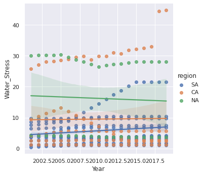

```python
sns.set_theme()
sns.lmplot(
    data=drop_dups,
    x="Year", y="Water_Stress", hue="region",
    fit_reg=True
)
```

From this graph, it looks like the region does have an impact on the level of water stress. So now I am going to look at each region, specifically, I am first going to look at the correlation values between columns and then graph them.

```python
print("Correlation between dependency and water stress: ", drop_dups['Dependency_Ratio'].corr(drop_dups['Water_Stress']))
print("Correlation between fresh water withdrawal and water stress: ", drop_dups['Fresh_Water'].corr(drop_dups['Water_Stress']))
print("Correlation between total renewable water and water stress: ", drop_dups['Total_renewable'].corr(drop_dups['Water_Stress']))
```

```
Correlation between dependency and water stress:  -0.21020604388897385
Correlation between fresh water withdrawal and water stress:  0.9786210359578372
Correlation between total renewable water and water stress:  -0.3093873277806207
```

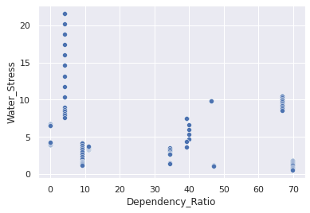

```python
sns.set_theme()
sns.scatterplot(
    data=SA,
    x="Dependency_Ratio", y="Water_Stress"
)
```

This graph shows that there really is nothing that can be gleaned from the dependency ratio in regards to the water stress

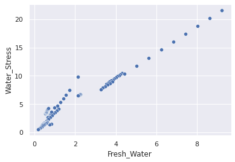

```python
sns.scatterplot(
    data=SA,
    x="Fresh_Water", y="Water_Stress"
)
```

This graph shows that there is a strong correlation between the fresh_water withdrawal and the water stress

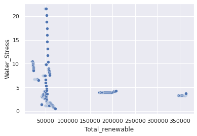

```python
sns.scatterplot(
    data=SA,
    x="Total_renewable", y="Water_Stress"
)
```

This graph shows that there really is nothing that can be gleaned from the total_renewable water source in regards to the water stress

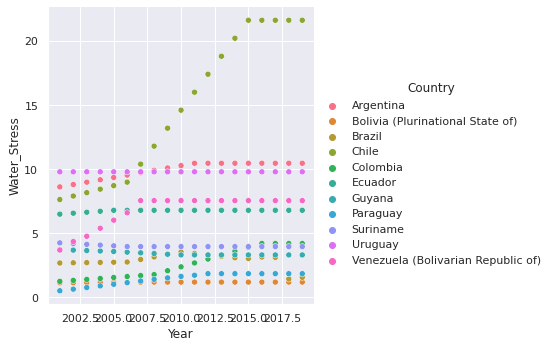

```python
sns.relplot(
    data=SA,
    x="Year", y="Water_Stress",
    hue="Country"
)
```

This graph shows that the water stress greatly differs based on the country that you are in, this should be used when predicting the water stress.

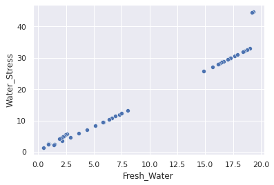

```python
sns.scatterplot(
    data=CA,
    x="Fresh_Water", y="Water_Stress"
)
```

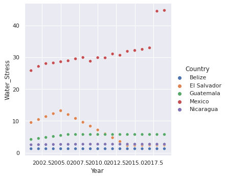

```python
sns.relplot(
    data=CA,
    x="Year", y="Water_Stress", hue="Country"
)
```

The above graphs show the same thing that the South American region showed, supporting the conclusions.

# Data Analysis and Regression

From these graphs and exploration we can see that when trying to predict the water stress it is important to consider the region, the freshwater withdrawal, and the country. So, now we will try fit a model and look at the summary to determine the p-values and see if our variables make sense.

```python
train=drop_dups.sample(frac=0.8,random_state=200)
test=drop_dups.drop(train.index)

reg = smf.ols(formula='Water_Stress ~ Year+C(region)+Fresh_Water+C(Country)', data=train).fit()
print(reg.summary())
```

```
                            OLS Regression Results
==============================================================================
Dep. Variable:           Water_Stress   R-squared:                       0.990
Model:                            OLS   Adj. R-squared:                  0.989
Method:                 Least Squares   F-statistic:                     1339.
Date:                Fri, 16 Dec 2022   Prob (F-statistic):          1.90e-242
Time:                        23:00:45   Log-Likelihood:                -357.32
No. Observations:                 274   AIC:                             754.6
Df Residuals:                     254   BIC:                             826.9
Df Model:                          19
Covariance Type:            nonrobust
====================================================================================================================
                                                       coef    std err          t      P>|t|      [0.025      0.975]
--------------------------------------------------------------------------------------------------------------------
Intercept                                          -77.6367     18.017     -4.309      0.000    -113.118     -42.156
C(region)[T.NA]                                     -7.6520      1.791     -4.273      0.000     -11.179      -4.125
C(region)[T.SA]                                     -9.5080      2.701     -3.520      0.001     -14.827      -4.189
C(Country)[T.Belize]                               -10.5739      2.752     -3.842      0.000     -15.994      -5.154
C(Country)[T.Bolivia (Plurinational State of)]      -0.9486      0.424     -2.236      0.026      -1.784      -0.113
C(Country)[T.Brazil]                                -0.0546      0.392     -0.139      0.889      -0.826       0.717
C(Country)[T.Canada]                                -1.9613      1.009     -1.943      0.053      -3.949       0.026
C(Country)[T.Chile]                                  0.0498      0.366      0.136      0.892      -0.671       0.771
C(Country)[T.Colombia]                              -0.2606      0.402     -0.648      0.517      -1.052       0.531
C(Country)[T.Ecuador]                                0.6878      0.369      1.864      0.063      -0.039       1.414
C(Country)[T.El Salvador]                          -12.8649      2.719     -4.731      0.000     -18.220      -7.510
C(Country)[T.Guatemala]                            -10.7230      2.760     -3.885      0.000     -16.159      -5.287
C(Country)[T.Guyana]                                 1.0073      0.422      2.388      0.018       0.177       1.838
C(Country)[T.Mexico]                               -16.1276      2.741     -5.884      0.000     -21.526     -10.730
C(Country)[T.Nicaragua]                            -10.1873      2.756     -3.696      0.000     -15.615      -4.760
C(Country)[T.Paraguay]                              -0.9494      0.407     -2.332      0.020      -1.751      -0.148
C(Country)[T.Suriname]                               1.2957      0.411      3.152      0.002       0.486       2.105
C(Country)[T.United States of America]              -5.6907      0.993     -5.734      0.000      -7.645      -3.736
C(Country)[T.Uruguay]                                3.9605      0.371     10.682      0.000       3.230       4.691
C(Country)[T.Venezuela (Bolivarian Republic of)]     2.1618      0.384      5.628      0.000       1.405       2.918
Year                                                 0.0440      0.010      4.264      0.000       0.024       0.064
Fresh_Water                                          2.1159      0.062     34.102      0.000       1.994       2.238
==============================================================================
Omnibus:                      378.895   Durbin-Watson:                   2.013
Prob(Omnibus):                  0.000   Jarque-Bera (JB):            47739.146
Skew:                           6.383   Prob(JB):                         0.00
Kurtosis:                      66.392   Cond. No.                     8.58e+19
==============================================================================

Notes:
[1] Standard Errors assume that the covariance matrix of the errors is correctly specified.
[2] The smallest eigenvalue is 1.5e-31. This might indicate that there are
strong multicollinearity problems or that the design matrix is singular.
```

The above shows that based on the year and fresh water, the p-value is incredibly small. However when looking at the different countries some have very high values, these are possible outliers in the dataset.

```python
values_predicted = reg.predict(test).values
values_actual = test.Water_Stress.values


correct = 0
for idx, value in enumerate(values_actual):
  if (value >= (values_predicted[idx] - .5)) & (value <= (values_predicted[idx] + .5)):
    correct += 1

correct/len(test)
```

```
0.8823529411764706
```

# Conclusion